# 18. praktikum

22.04.2026

# Juhumetsad

## Tänases praktikumis

- Juhumetsad
- Juhumetsade visualiseerimine
- Juhumetsade headuse näitajad

Nagu eelmises praktikumis räägitud, ei pruugi üksikud otsustuspuud olla väga stabiilised. Ehkki need sobivad hästi andmestiku visualiseerimiseks ja nendes esinevate olulisemate seoste tuvastamiseks, ei ole need uue valimi pealt ennustamiseks alati kõige paremad, eriti kui puid ei ole trimmitud. Üks variant otsustuspuude valideerimiseks oli kasutada treening- ja testandmestikke. Teine variant on aga kasutada nn **ansamblimeetodeid** (*ensemble methods*), mis kasutavad sageli *[bootstrap](https://www.statisticshowto.com/bootstrap-sample/)*-valikut ning milles lõplik ennustus uuritava tunnuse väärtustele üldistatakse mitmete üksikute puumudelite põhjal. Ka ansamblimeetoditele on palju algoritme, põhilistena eristatakse nn *bagging*- ja *boosting*-algoritme.

- *Bagging*-algoritmides treenitakse paralleelselt mitut mudelit mitme üksteisest pisut erineva juhusliku valimi peal ning üldistatakse lõpuks nende mudelite ennustused.
- *Boosting*-algoritmides treenitakse mudeleid järjekorras ja iga järgmine mudel saab midagi eelmiselt mudelilt õppida. Ühes puus valesti klassifitseeritud vaatlused saavad järgmises puus suurema kaalu.

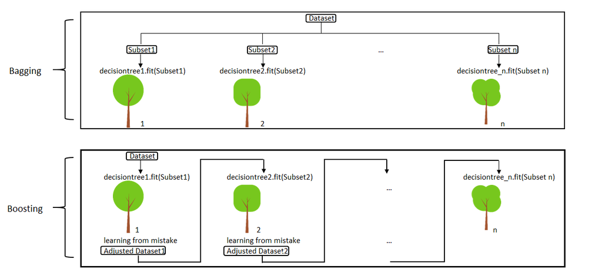

*Bagging ja boosting, https://miro.medium.com/max/2000/1*bUySDOFp1SdzJXWmWJsXRQ.png*

Vaatame lähemalt nn **juhumetsa meetodit** (*random forest*), mis on *bagging*-algoritmi eritüüp.

## Juhumets

**Juhumets** (*random forest*) on mudel, mis üldistab oma ennustused terve hulga juhuslike puude põhjal. Juhuslikkus tuleneb sealjuures kahest asjaolust:

- andmestikust võetakse mingi hulk **juhuslikke valimeid** (kas *bootstrap*-valimeid ehk sama suuri valimeid, kus mõni vaatlus/rida võib korduda, mõni aga jääb välja, või väiksemaid valimeid, milles vaatlused/read korduda ei või) ja igast valimist kasvatatakse puumudel. Vaatlused, mis valimisse ei satu, on nn **out-of-bag** ehk **OOB**-vaatlused. Iga puu võib teistest natuke erineda, sest tema aluseks olev valim on veidi erinev. See on tavaline *bagging*-algoritmi põhimõte;
- iga juhusliku puu igas sõlmes kaalutakse jagunemiseks **juhuslikku hulka kõigist seletavatest tunnustest**. See loob veelgi erinevamad puud ja annab hääle ka nõrgematele seletavatele tunnustele (kui mõni väga tugev tunnus, nt meie adessiivi ja *peal*-andmestikus tunnus `LM_mobiilsus`, esimese sõlme jagunemise valikusse ei satu). See on see, mille poolest juhumets tavalisest *bagging*’ust erineb.

Lõpliku ennustuse saamiseks puud “hääletavad” iga tegeliku vaatluse ennustatud klassi üle, kui uuritav tunnus on kategoriaalne, või keskmistavad tegeliku vaatluse ennustatud väärtuse, kui uuritav tunnus on arvuline. See tähendab, et iga andmestiku tegelik vaatlus saab mingi ühe ennustatud klassi või keskväärtuse, olenemata sellest, millised need üksikud puumudelid välja näevad.

*Out-of-bag* vaatlused (iga juhusliku valimi puhul umbes kolmandik andmestikust) toimivad hiljem iga puu n-ö sisseehitatud testandmestikuna.

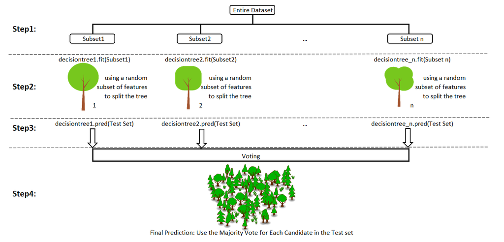

Juhumets, https://miro.medium.com/max/2000/1*jXkT3mj1mCqMaX5SqU1wNw.png

Kasutame endiselt andmestikke `ade_peal.csv` ja `kandidaadid_2023.csv`.

```r
ade_peal <- read.delim("data/ade_peal.csv", encoding = "UTF-8", stringsAsFactors = TRUE)
ade <- ade_peal[ade_peal$cx == "ade",] # ainult alalütleva käände andmed
peal <- ade_peal[ade_peal$cx == "peal",] # ainult peal-kaassõna andmed

set.seed(1) # seeme juhusliku valiku tegemise korratavuseks
juh_id <- sample(x = 1:nrow(peal), # võta ridadelt 1 kuni 1310 juhuslik valim,
                 size = nrow(ade), # mille suurus oleks sama, mis ade-andmestikul
                 replace = F) # ära korda ühtegi vaatlust

peal_juhuvalim <- peal[juh_id,] # võta peal-andmestikust ainult juhuslikult valitud read
dat <- droplevels(rbind(ade, peal_juhuvalim)) # liida kaks andmestikku ridupidi uuesti kokku
```

```r
kandidaadid <- read.delim("data/kandidaadid_2023.csv", header = T, sep = "\t", encoding = "UTF-8")

# Teeme juurde tunnused "kasutab_meili", "nime_pikkus" ja "vanus"
kandidaadid$kasutab_meili <- factor(ifelse(grepl("@", kandidaadid$kontakt),
                                               "jah",
                                               "ei"))

kandidaadid$nime_pikkus <- nchar(kandidaadid$nimi)
kandidaadid$vanus <- 2023 -as.numeric(substr(kandidaadid$sünniaeg, 7, 10))
```

## randomForest

Kasutame alustuseks funktsiooni `randomForest()` samanimelisest paketist. See on kõige põhilisem juhumetsade tegemise pakett, kuna on kasutajasõbralik, lihtne õppida ja arvutuslikult võrdlemisi kiire.

Funktsiooni miinuseks on see, et puid vaikimisi ei trimmita ning need võivad ülesobitada. Samuti kalduvad puud eelistama sõlmedes arvulisi tunnuseid ja kategoriaalseid tunnuseid, millel on palju tasemeid. Selles paketis ei tehta niisiis tingimuslikke otsustuspuid, mis kasutavad sõlmedes jagunemiseks valitavate tunnuste määramiseks *p*-väärtuseid, vaid tavalisi regressiooni- ja klassifitseerimispuid (vt ka 17. praktikumi materjale).

```r
# install.packages("randomForest")
library(randomForest)
```

```r
# Kategoriaalne uuritav tunnus

# Kuna juhumetsade mudelid sisaldavad juhuslikkust,
# tuleks tulemuste korratavuse huvides mudeldamisel
# alati määrata ka seeme (seed),
# mis tagab juhuslikkuses teatud fikseeritud seisu.
# Seemneks sobib mis tahes arv.
set.seed(100)
mets_kat_rf <- randomForest(cx ~ TR_liik + tegusõna_klass + LM_mobiilsus + LM_komplekssus + LM_pikkus_log + sõnajärg + murderühm,
                            data = dat,
                            importance = TRUE)
# Argumendi `importance` lisamine võimaldab meil hiljem võrrelda tunnuste olulisust
# nii nende täpsuse kui ka klasside puhtuse suurendamise seisukohalt.
```

```r
class(mets_kat_rf) # objektiklass on randomForest
mets_kat_rf$type # metsamudel kasutab klassifitseerimispuid (<- kat. uuritav tunnus)
```

```r
mets_kat_rf # metsamudeli väljund
```

```
##
## Call:
##  randomForest(formula = cx ~ TR_liik + tegusõna_klass + LM_mobiilsus +      LM_komplekssus + LM_pikkus_log + sõnajärg + murderühm,      data = dat, importance = TRUE)
##                Type of random forest: classification
##                      Number of trees: 500
## No. of variables tried at each split: 2
##
##         OOB estimate of  error rate: 31.44%
## Confusion matrix:
##      ade peal class.error
## ade  478  244   0.3379501
## peal 210  512   0.2908587
```

Vaikimisi tehakse 500 puumudelit ja iga puu igas sõlmes katsetatakse jagunemiseks 2 juhuslikult valitud tunnust. Enamasti on see arv ruutjuur seletavate tunnuste arvust, mille `randomForest` ümardab allapoole. Antud juhul näiteks on meil mudelis 7 seletavat tunnust, millest ruutjuur on 2.645751. Kui see allapoole ümardada, saabki 2.  
Sellise metsa **eksimismäär** (*OOB estimate of error rate*) on **31.44%**, mis tähendab, et **klassifitseerimistäpsus** on 100-31.44=**68.56%**. Täpsust arvutatakse nn *out-of-bag* vaatluste põhjal.

- Iga puu tehakse andmestiku põhjal, mis algandmestikust veidi erineb. Umbes 1/3 algandmestiku vaatlustest jäetakse iga puumudeli aluseks olevast valimist välja, kusjuures seda 1/3 korvatakse sellega, et korratakse mingeid vaatlusi ülejäänud 2/3st vaatlustest. Need **1/3 väljajäänud vaatlusi ongi *out-of-bag* vaatlused**, mida kasutatakse testandmestikuna, et leida iga puu individuaalne klassifitseerimistäpsus.
- Metsamudeli lõplik klassifitseerimistäpsus üldistatakse seejärel kõikide puude põhjal: iga algandmestiku vaatluse/rea puhul hääletavad kõik 500 puud selle üle, mis mingile vaatlusele klassiks määratakse. Näiteks käsk `mets_kat_rf$votes[1,]` näitab, et 70% puudest ennustab, et meie andmestiku 1. real olev vaatlus ei esinda *peal*-konstruktsiooni esinemisjuhtu, 30% puudest aga ennustab, et esindab küll. Kuna üldsus otsustab, siis saab 1. vaatlus metsamudeli ennustusena *peal*-konstruktsiooni esinemisele väärtuse “ei”. Nii ennustatakse klassi kõigi 1444 vaatluse puhul algandmestikus. *OOB estimate of error rate* näitab niisiis nende vaatluste osakaalu, mille puhul metsamudel ennustas valet uuritava tunnuse väärtust. Mida väiksem see protsent on, seda parem.

`randomForesti` mudel annab väljundis automaatselt ka **õigete ja valede ennustuste risttabeli** ehk *confusion matrix*’i (ridades tegelikud vaatlused ning tulpades ennustatud klassid) ning lisaks iga klassi eksimismäära eraldi (`class.error`). See on kasulik, kuna vahel võib juhtuda, et mudel suudab ennustada väga hästi üht, aga mitte teist klassi.

```r
mets_kat_rf$confusion
```

```
##      ade peal class.error
## ade  478  244   0.3379501
## peal 210  512   0.2908587
```

Saame binaarse kategoriaalse uuritava tunnusega metsamudeli ennustuste põhjal leida jällegi ka **C/AUC**.

```r
# Leiame metsamudeli ennustatud tõenäosused "peal"-konstruktsioonile
enn_probs <- predict(mets_kat_rf, type = "prob")[,"peal"]
head(enn_probs)
```

```
##          6          7          8          9         11         13
## 0.30386740 0.06521739 0.01500000 0.94594595 0.80459770 0.56140351
```

```r
# C-indeks
library(pROC)
auc(dat$cx, enn_probs) # teg, enn, tegelikud väärtused kategooriatena
```

```
## Area under the curve: 0.7378
```

```r
# või
# Teisendame uuritava tunnuse tegelikud väärtused
# samuti tõenäosusteks 0 ("ade") ja 1 ("peal")
teg_probs <- ifelse(dat$cx == "peal", 1, 0)
head(teg_probs)
```

```
## [1] 0 0 0 0 0 0
```

```r
# C-indeks
library(Hmisc)
somers2(enn_probs, teg_probs)["C"] # enn, teg, mõlemad argumendid tõenäosustena
```

```
##         C
## 0.7378377
```

Vaatame ka arvulise uuritava tunnusega mudeli väljundit.

```r
# Arvuline uuritav tunnus
set.seed(100)
mets_num_rf <- randomForest(log(hääli_kokku) ~ haridus + sugu + tähtkuju + kasutab_meili + nime_pikkus + vanus,
                            data = kandidaadid,
                            subset = haridus != "Põhiharidus",
                            importance = TRUE)

class(mets_num_rf)
```

```
## [1] "randomForest.formula" "randomForest"
```

```r
mets_num_rf$type # metsamudel kasutab regressioonipuid (<- arv. uuritav tunnus)
```

```
## [1] "regression"
```

```r
mets_num_rf
```

```
##
## Call:
##  randomForest(formula = log(hääli_kokku) ~ haridus + sugu +      tähtkuju + kasutab_meili + nime_pikkus + vanus, data = kandidaadid,      importance = TRUE, subset = haridus != "Põhiharidus")
##                Type of random forest: regression
##                      Number of trees: 500
## No. of variables tried at each split: 2
##
##           Mean of squared residuals: 1.902888
##                     % Var explained: -2.53
```

Arvulise uuritava tunnusega tehakse samuti 500 puud, ent regressioonipuude metsas valitakse igas sõlmes vaatluste jaotamiseks *p*/3 seletava tunnuse vahel, kus *p* on seletavate tunnuste arv. Kuna siin on seletavate tunnuste arv mudelis 6, siis proovitakse igas sõlmes jagunemiseks 6/3=2 juhuslikult valitud tunnust.

Regressioonipuud näitavad klassifitseerimistäpsuse asemel **seletatud varieerumise protsenti** *% Var explained*, mis on põhimõtteliselt sama, mis R<sup>2</sup> (tegelikult pseudo-R<sup>2</sup>). *Mean of squared residuals* näitab ruutu võetud jääkide keskmist. Selle absoluutarv sõltub uuritava arvulise tunnuse skaalast. Siin on arvuline tunnus logaritmitud häältesaak, mille väärtused võivad üldse varieeruda ainult 0 ja 10.37 vahel (vt `range(log(kandidaadid$hääli_kokku))`). Seepärast on väike ka ruutu võetud jääkide keskmine, võrreldes näiteks reaktsiooniaegade andmestikuga, kus uuritav tunnus on mõõdetud millisekundites ja ruutu võetud jääkide keskmine võib olla seega tuhandetes. Sama andmestiku peal tehtud mudelite võrdlusel on aga väiksem *Mean of squared residuals* parem.

## Tunnuste olulisus

Juhumetsade mudelite üks suuri plusse on see, et need võimaldavad hinnata mudelisse kaasatud seletavate tunnuste suhtelist olulisust uuritava tunnuse väärtuste ennustamisel. Seletavate tunnuste olulisust saab küsida funktsiooniga `importance()`.

Vaatame esmalt jällegi kategoriaalse uuritava tunnusega mudelit.  
Juhul, kui `randomForest()`-funktsioonis on metsamudeli tegemisel eelnevalt täpsustatud argument `importance = TRUE`, saame lisaks Gini-informatsioonikriteeriumile ka nn permutatsiooniolulisuse.

```r
importance(mets_kat_rf)
```

```
##                       ade      peal MeanDecreaseAccuracy MeanDecreaseGini
## TR_liik        10.1410582  7.269014           13.0506235         27.56134
## tegusõna_klass 10.2982033 12.065587           16.2809698         44.24411
## LM_mobiilsus   48.1838446 43.887712           57.3769924         55.21036
## LM_komplekssus 26.1693446 13.412225           30.7603178         21.66096
## LM_pikkus_log  23.0053999 10.150189           25.2397845         45.51921
## sõnajärg        0.6633584 -1.142801           -0.4320659         10.99076
## murderühm      27.7322377 24.403970           34.2147467         50.48720
```

`randomForest` esitab tunnuste olulisust niisiis kahe mõõdiku järgi:

- `MeanDecreaseAccuracy` näitab nn **permutatsiooniolulisust** ehk **keskmist kahanemist klassifitseerimistäpsuses, kui konkreetset seletavat tunnust on kõikides puudes permuteeritud**. Permuteerimine on protsess, kus OOB-vaatlustel (nendel ridadel, mida ei kasutatud puu konstrueerimiseks) aetakse mingi seletava tunnuse (nt `TR_liik`) väärtused suvaliselt sassi ning ennustatakse siis uuesti uuritava tunnuse väärtusi. Mida rohkem seletava tunnuse väärtuste sassiajamine suurendab valesti klassifitseerimist, seda suurem on ka tunnuse olulisus, sest seda paremini aitab seletava tunnuse tegelike väärtuste teadmine ennustada uuritava tunnuse väärtust. Kui aga seletaval tunnusel ei ole uuritava tunnuse varieerumisele olulist mõju, siis ei muutu klassifitseerimistäpsus, kui seletava tunnuse väärtusi suvaliselt muuta. Kui `MeanDecreaseAccuracy` on negatiivne, nagu näiteks meil tunnuse `sõnajärg` puhul, tähendab see seda, et seletava tunnuse väärtuste suvaline sassiajamine tegelikult isegi parandaks klassifitseerimistäpsust, mis jällegi viitab sellele, et tunnusel ei ole uuritava tunnuse varieerumisele mingit mõju.
- `MeanDecreaseGini` põhineb lehtede puhtusel ja **Gini-informatsioonikriteeriumil**, millest rääkisime juba ka otsustuspuude juures. Mida suurem on *MeanDecreaseGini*, seda enam aitab tunnus kaasa sellele, et puude sõlmedesse ennustatud vaatlused oleksid uuritava tunnuse seisukohalt võimalikult homogeensed (nt sisaldaksid võimalikult palju ainult *peal*-konstruktsiooni kasutusjuhte või ainult *ade*-konstruktsiooni kasutusjuhte). Gini-mõõdik kaldub eelistama arvulisi tunnuseid ja selliseid kategoriaalseid tunnuseid, millel on mitu taset. Näiteks on `mets_kat_rf` mudelis peale tunnuse `LM_mobiilsus`, mis ilmselt ongi põhiline varieerumise seletaja, selle mõõdiku põhjal järgmiseks kõige olulisemad kategoriaalne tunnus `murderühm`, millel on 4 taset, arvuline tunnus `LM_pikkus_log` ja `tegusõna_klass`, millel on tervelt 5 taset. Seega on parem tunnuste olulisuse hindamisel lähtuda permutatsiooniolulisusest, mis on vähem kallutatud.

Kaks esimest tulpa tabelis (`ade` ja `peal`) näitavad, kui palju kasvas mingi tunnuse permuteerimisel vastavalt *ade* ja *peal* vaatluste valesti klassifitseerimine. Näiteks tunnuse `LM_mobiilsus` permuteerimine suurendaks enam-vähem ühepalju nii *ade*- kui ka *peal*-konstruktsioonide valesti klassifitseerimist, tunnused `LM_komplekssus` ja `LM_pikkus_log` on aga olulisemad *ade*-konstruktsioonide õigesti klassifitseerimiseks.

“Toored” permutatsiooniolulisuse skoorid saadakse nii, et iga puu puhul lahutatakse “puutumata” OOB-vaatluste õigesti klassifitseeritud juhtude arvust permuteeritud OOB-vaatluste õigesti klassifitseeritud juhtude arv ning leitakse saadud arvu kõikide puude keskmine. `importance()`-funktsioon näitab aga permutatsiooniolulisuse puhul vaikimisi nn [*z*-skoore](https://www.statisticshowto.com/probability-and-statistics/z-score/) ehk jagab permutatsiooniolulisuse mõõdikud läbi nende standardvigadega. Vahel on soovitatud kasutada siiski neid “tooreid”, standardiseerimata (`scale = FALSE`) olulisusmõõdikuid, kuna *z*-skoorid on tundlikumad valimi suuruse ja puude arvu suhtes.

```r
# standardiseerimata mõõdikud
importance(mets_kat_rf, scale = FALSE)
```

```
##                         ade          peal MeanDecreaseAccuracy MeanDecreaseGini
## TR_liik        0.0116139290  0.0081223034         0.0098838676         27.56134
## tegusõna_klass 0.0122942829  0.0147071382         0.0134642965         44.24411
## LM_mobiilsus   0.0677285606  0.0723647329         0.0699601955         55.21036
## LM_komplekssus 0.0232493598  0.0101849629         0.0167184240         21.66096
## LM_pikkus_log  0.0318145298  0.0117155374         0.0217415671         45.51921
## sõnajärg       0.0005364291 -0.0009333887        -0.0002239436         10.99076
## murderühm      0.0369555710  0.0327512770         0.0347973662         50.48720
```

Tunnuste olulisust esitatakse tihtipeale ka graafikul. Paketil `randomForest` on selleks sisse-ehitatud funktsioon `varImpPlot()`.

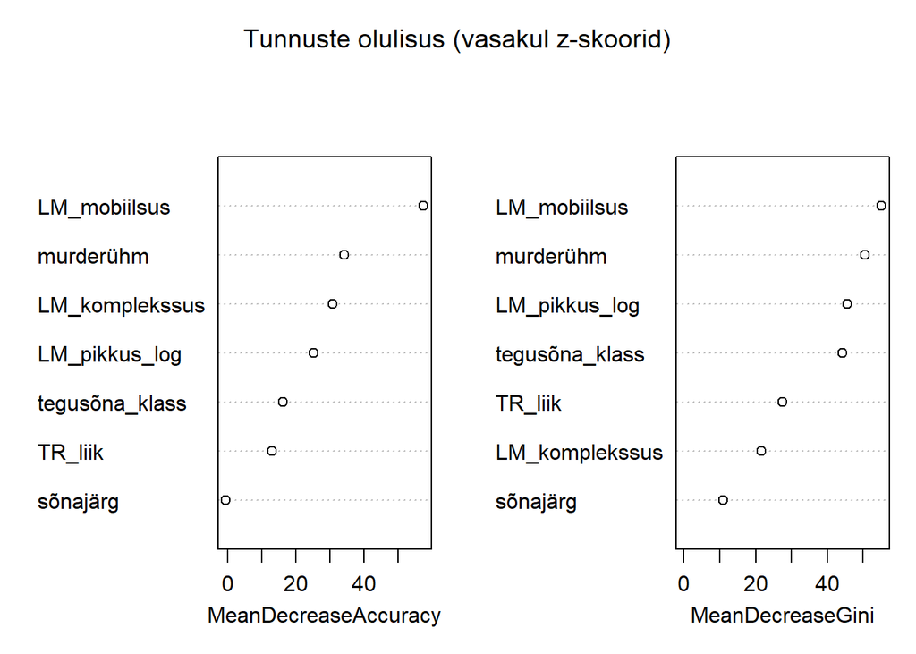

```r
varImpPlot(mets_kat_rf,
           main = "Tunnuste olulisus (vasakul z-skoorid)")
```

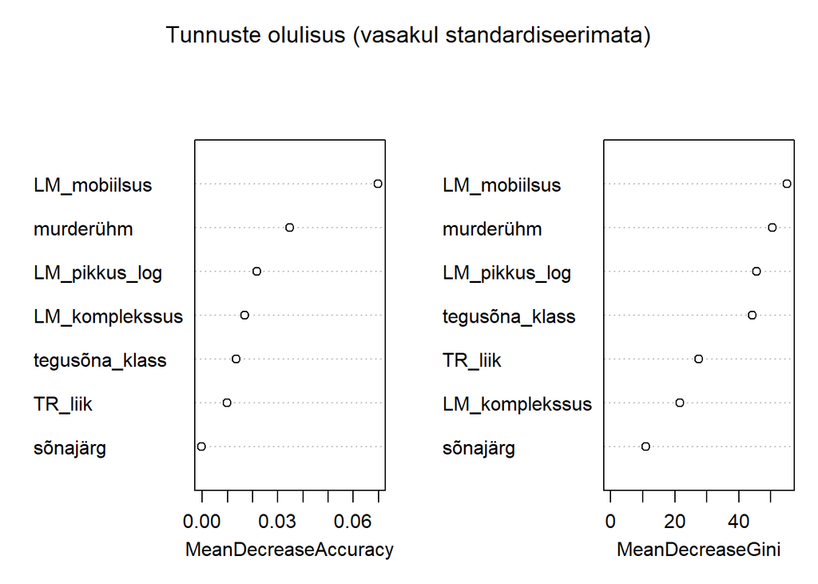

```r
varImpPlot(mets_kat_rf,
           main = "Tunnuste olulisus (vasakul standardiseerimata)",
           scale = FALSE)
```

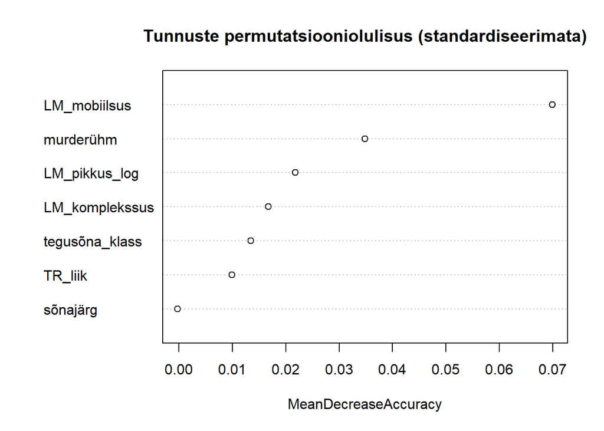

```r
varImpPlot(mets_kat_rf,
           main = "Tunnuste permutatsiooniolulisus (standardiseerimata)",
           scale = FALSE,
           type = 1)
```

Tunnuste olulisust võib visualiseerida ka nt `ggplot2`-ga.

```r
library(ggplot2)

# Tee olulisuse mõõdikutest andmetabel
df <- as.data.frame(importance(mets_kat_rf, scale = FALSE))
head(df)
```

```
##                         ade          peal MeanDecreaseAccuracy MeanDecreaseGini
## TR_liik        0.0116139290  0.0081223034         0.0098838676         27.56134
## tegusõna_klass 0.0122942829  0.0147071382         0.0134642965         44.24411
## LM_mobiilsus   0.0677285606  0.0723647329         0.0699601955         55.21036
## LM_komplekssus 0.0232493598  0.0101849629         0.0167184240         21.66096
## LM_pikkus_log  0.0318145298  0.0117155374         0.0217415671         45.51921
## sõnajärg       0.0005364291 -0.0009333887        -0.0002239436         10.99076
```

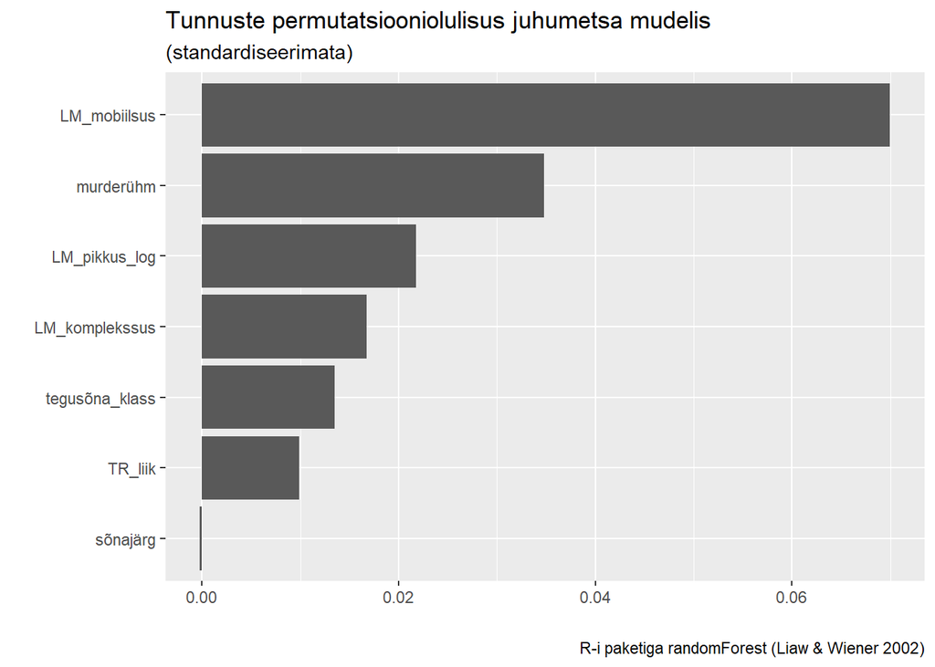

```r
# Joonista ggploti graafik
ggplot(data = df,
       aes(y = reorder(rownames(df), MeanDecreaseAccuracy), # y-teljele tabeli df reanimed tunnustega, mis on järjestatud permutatsiooniolulisuse skoori järgi
           x = MeanDecreaseAccuracy)) + # x-teljele perm.olulisus
  geom_col() + # tulpdiagramm
  labs(x = "", y = "",
       title = "Tunnuste permutatsiooniolulisus juhumetsa mudelis",
       subtitle = "(standardiseerimata)",
       caption = "R-i paketiga randomForest (Liaw & Wiener 2002)")
```

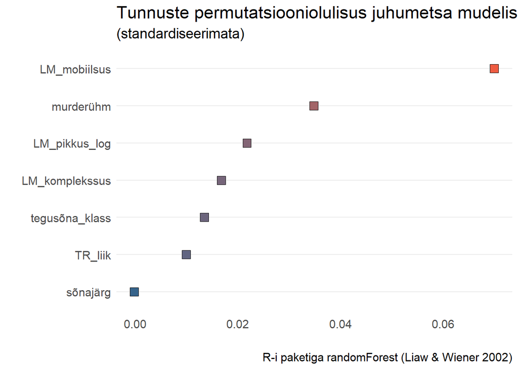

```r
# Teistsugune graafik
ggplot(data = df,
       aes(y = reorder(rownames(df), MeanDecreaseAccuracy),
           x = MeanDecreaseAccuracy,
           fill = MeanDecreaseAccuracy)) + # punktide värv
  geom_point(size = 4, shape = 22, show.legend = FALSE) + # punktid
  scale_fill_gradient(low = "steelblue4", # mitteoluliste värv
                      high = "tomato2") + # oluliste värv
  labs(x = "",
       y = "",
       title = "Tunnuste permutatsiooniolulisus juhumetsa mudelis",
       subtitle = "(standardiseerimata)",
       caption = "R-i paketiga randomForest (Liaw & Wiener 2002)") +
  theme_minimal() +
  theme(text = element_text(size = 14),
        panel.grid.minor = element_blank(),
        panel.grid.major.x = element_blank())
```

Vaatame ka **arvulise uuritava tunnusega metsamudeli tunnuste olulisust**.

```r
importance(mets_num_rf)
```

```
##                 %IncMSE IncNodePurity
## haridus       14.488174      41.40613
## sugu           3.836047      38.66479
## tähtkuju       1.753878     170.51391
## kasutab_meili  3.305421      13.50634
## nime_pikkus    8.549109     189.57093
## vanus          5.210100     305.64053
```

- Arvulise uuritava tunnusega metsamudeli puhul näitab esimene tulp `%IncMSE` seda, kui palju mingi seletava tunnuse permuteerimine (segiajamine) suurendab nn keskmist ruutviga (*mean squared error*) ehk OOB-vaatluste põhjal ennustatud väärtuste ja algandmestiku tegelike väärtuste keskmisi erinevusi. **Mida suurem selle tulba väärtus on, seda rohkem mõjutab vastav tunnus seda, kui hästi me mudeliga vaatluste uuritava tunnuste väärtusi saame ennustada, ning seda olulisem tunnus on.**
- Sellega on osaliselt seotud ka teine tulp, `IncNodePurity`, mis näitab, kui palju mingi tunnuse põhjal andmete ositamine puudes suurendab puu sõlmedes uuritava tunnuse väärtuste homogeensust ehk ühetaolisust ning erinevust teistes sõlmedes olevate vaatluste uuritava tunnuse väärtustest. **Mida suurem on mingi seletava tunnuse `IncNodePurity` väärtus, seda erinevamad on selle tunnuse alusel binaarsel ositamisel tekkivad rühmad üksteisest ning seda sarnasemad rühmadesse kuuluvad vaatlused omavahel.** `IncNodePurity`’t peetakse aga suhteliselt kallutatud mõõdikuks, sest seegi eelistab jällegi arvulisi tunnuseid ning mitme tasemega kategoriaalseid tunnuseid, nii et enamasti võiks seletavate tunnuste olulisuse hindamisel eelistada `%IncMSE`-d.

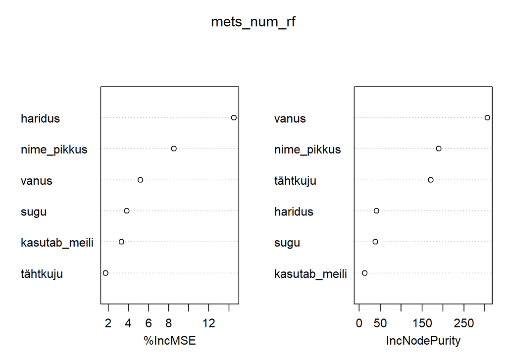

```r
varImpPlot(mets_num_rf)
```

## Puude ja tunnuste arv

Nagu öeldud, teeb R vaikimisi mudeli, kus kasvatatakse 500 puud ja proovitakse iga puu igas sõlmes nii mitut juhuslikult valitud tunnust, kui suur on ruutjuur seletavate tunnuste arvust (arvulistel tunnustel seletavate tunnuste arv / 3). Neid parameetreid saab aga soovi korral muuta vastavalt argumentidega `ntree` ja `mtry`.

```r
mets_kat_rf$ntree
```

```
## [1] 500
```

```r
mets_kat_rf$mtry
```

```
## [1] 2
```

Vaatame, kas mudeli täpsus paraneb, kui proovime sõlmedes erineval hulgal seletavaid tunnuseid.

```r
# Teeme tühja vektori
tapsused <- vector()

# Teeme tsükli, kus
for(i in 2:7){ # iga arvu i kohta 2st 7ni (i = 2, i = 3, i = 4, i = 5, i = 7)

  set.seed(100)
  # teeme mudeli, kus seletavate tunnuste arv võrdub i-ga
  # (nt mudel, kus mtry = 1; mudel, kus mtry = 2 jne,
  # kuni mudelini, kus mtry = 7)
  mudel <- randomForest(cx ~ TR_liik + tegusõna_klass + LM_mobiilsus + LM_komplekssus + LM_pikkus_log + sõnajärg + murderühm,
                        data = dat,
                        mtry = i)

  # ja lisame tapsuste vektorisse iga mudeli klassifitseerimistäpsuse
  # see on sama klassifitseerimistäpsus, mida varem table-käsu abil arvutasime
  # (i-1 tähendab, et kui i on 2, siis pane täpsus
  # vektorisse esimeseks elemendiks, mitte teiseks)
  tapsused[i-1] <- sum(diag(mudel$confusion))/sum(mudel$confusion[1:4])
}

tapsused
```

```
## [1] 0.6835180 0.6675900 0.6537396 0.6523546 0.6537396 0.6544321
```

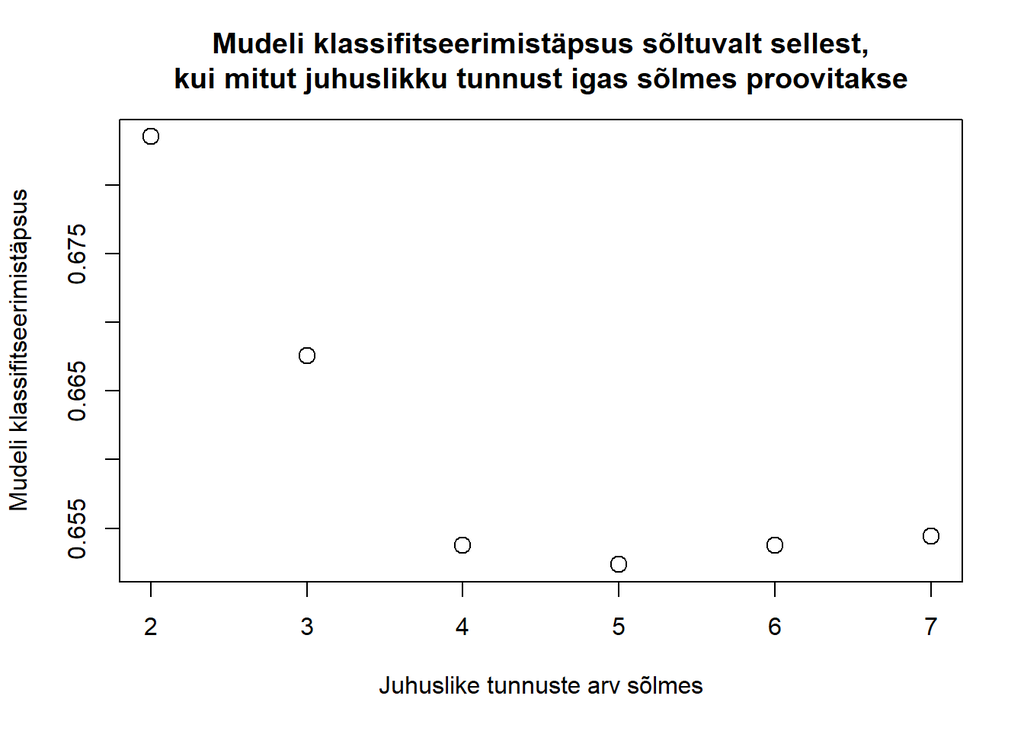

```r
plot(x = 2:7, y = tapsused,
     cex = 1.5,
     xlab = "Juhuslike tunnuste arv sõlmes",
     ylab = "Mudeli klassifitseerimistäpsus",
     main = "Mudeli klassifitseerimistäpsus sõltuvalt sellest,\nkui mitut juhuslikku tunnust igas sõlmes proovitakse")
```

Näeme, et 2 tunnust igas sõlmes on meie mudeli jaoks tõepoolest optimaalne väärtus, sest rohkematega läheb klassifitseerimistäpsus alla.

Vaatame, kas mudeli täpsus paraneb, kui kasvatame erineval hulgal puid.

```r
# Võtab natuke aega...
tapsused2 <- vector()
puude_arv <- c(10, 100, 500, 1000, 1500, 2000, 3000, 4000)
n <- 1

# Teeme tsükli, kus...
for(i in puude_arv){ # iga arvu i kohta vektoris puude_arv

  set.seed(100)
  # teeme mudeli, kus kasvatatavate puude arv võrdub i-ga
  # (nt mudel, kus ntree = 10; mudel, kus ntree = 100 jne,
  # kuni mudelini, kus ntree = 4000)
  mudel <- randomForest(cx ~ TR_liik + tegusõna_klass + LM_mobiilsus + LM_komplekssus + LM_pikkus_log + sõnajärg + murderühm,
                        data = dat,
                        importance = TRUE,
                        ntree = i)

  tapsused2[n] <- sum(diag(mudel$confusion))/sum(mudel$confusion[1:4])
  n <- n+1
}

tapsused2
```

```
## [1] 0.6675997 0.6869806 0.6855956 0.6862881 0.6876731 0.6918283 0.6918283
## [8] 0.6918283
```

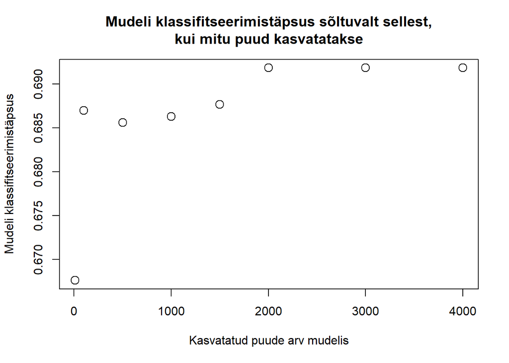

```r
plot(x = puude_arv, y = tapsused2,
     cex = 1.5,
     xlab = "Kasvatatud puude arv mudelis",
     ylab = "Mudeli klassifitseerimistäpsus",
     main = "Mudeli klassifitseerimistäpsus sõltuvalt sellest,\nkui mitu puud kasvatatakse")
```

Näeme, et puude arvu kasvades mudeli klassifitseerimistäpsus paraneb. Küll aga nõuab iga puu kasvatamine ressurssi, mistõttu mingist punktist alates ei ole täpsuse parandamine enam arvutuslikus mõttes mõistlik. Seega nt 2000 ja 4000 puu vahel enam erinevust ei ole. Täpset kriteeriumit puude arvu määramiseks aga paraku ei olegi.